# Data Preparation:

```python
#importing libraries

#Dataprep
import pandas as pd
from pandas import json_normalize
import json as j
import numpy as np
import matplotlib.pyplot as plt
import seaborn as sn
from scipy import stats
import plotly.graph_objects as go
import plotly.tools as tools
import plotly.offline as off

#Preprocessing
from sklearn import preprocessing
from sklearn.preprocessing import StandardScaler
from sklearn.model_selection import train_test_split
from sklearn.utils import resample

#Models
from sklearn.cluster import KMeans
from sklearn.ensemble import RandomForestClassifier
from sklearn.linear_model import LogisticRegression
from sklearn.naive_bayes import GaussianNB
from sklearn.decomposition import PCA

# Model Evaluation
from sklearn.metrics import confusion_matrix
from sklearn.metrics import accuracy_score
from sklearn.model_selection import cross_val_score
from sklearn.model_selection import cross_val_predict
from sklearn.metrics import classification_report
```

```python
json_col = ['device', 'geoNetwork', 'totals', 'trafficSource']
train_df = pd.read_csv('C:/Users/Gopinath/Downloads/train_project.csv',
                     converters={column: j.loads for column in json_col},
                     dtype={'fullVisitorId': 'str'}, nrows=300000)

for column in json_col:
        column_as_df = json_normalize(train_df[column])
        column_as_df.columns = [f"{column}.{subcolumn}" for subcolumn in column_as_df.columns]
        train_df = train_df.drop(column, axis=1).merge(column_as_df, right_index=True, left_index=True)
```

```python
const_columns = [c for c in train_df.columns if train_df[c].nunique(dropna=False)==1 ]
const_columns
```

```
['socialEngagementType',
 'device.browserVersion',
 'device.browserSize',
 'device.operatingSystemVersion',
 'device.mobileDeviceBranding',
 'device.mobileDeviceModel',
 'device.mobileInputSelector',
 'device.mobileDeviceInfo',
 'device.mobileDeviceMarketingName',
 'device.flashVersion',
 'device.language',
 'device.screenColors',
 'device.screenResolution',
 'geoNetwork.cityId',
 'geoNetwork.latitude',
 'geoNetwork.longitude',
 'geoNetwork.networkLocation',
 'totals.visits',
 'trafficSource.adwordsClickInfo.criteriaParameters']
```

```python
train_df = train_df.drop(const_columns,1)
```

```python
pd.set_option('display.max_columns', None)
train_df.head()
```

|  | channelGrouping | customDimensions | date | fullVisitorId | hits | visitId | visitNumber | visitStartTime | device.browser | device.operatingSystem | device.isMobile | device.deviceCategory | geoNetwork.continent | geoNetwork.subContinent | geoNetwork.country | geoNetwork.region | geoNetwork.metro | geoNetwork.city | geoNetwork.networkDomain | totals.hits | totals.pageviews | totals.bounces | totals.newVisits | totals.sessionQualityDim | totals.timeOnSite | totals.transactions | totals.transactionRevenue | totals.totalTransactionRevenue | trafficSource.campaign | … |
| --- | --- | --- | --- | --- | --- | --- | --- | --- | --- | --- | --- | --- | --- | --- | --- | --- | --- | --- | --- | --- | --- | --- | --- | --- | --- | --- | --- | --- | --- | --- |
| 0 | Organic Search | [{'index': '4', 'value': 'EMEA'}] | 20171016 | 3162355547410993243 | [{'hitNumber': '1', 'time': '0', 'hour': '17',... | 1508198450 | 1 | 1508198450 | Firefox | Windows | False | desktop | Europe | Western Europe | Germany | not available in demo dataset | not available in demo dataset | not available in demo dataset | (not set) | 1 | 1 | 1 | 1 | 1 | NaN | NaN | NaN | NaN | (not set) | … |
| 1 | Referral | [{'index': '4', 'value': 'North America'}] | 20171016 | 8934116514970143966 | [{'hitNumber': '1', 'time': '0', 'hour': '10',... | 1508176307 | 6 | 1508176307 | Chrome | Chrome OS | False | desktop | Americas | Northern America | United States | California | San Francisco-Oakland-San Jose CA | Cupertino | (not set) | 2 | 2 | NaN | NaN | 2 | 28 | NaN | NaN | NaN | (not set) | … |
| 2 | Direct | [{'index': '4', 'value': 'North America'}] | 20171016 | 7992466427990357681 | [{'hitNumber': '1', 'time': '0', 'hour': '17',... | 1508201613 | 1 | 1508201613 | Chrome | Android | True | mobile | Americas | Northern America | United States | not available in demo dataset | not available in demo dataset | not available in demo dataset | windjammercable.net | 2 | 2 | NaN | 1 | 1 | 38 | NaN | NaN | NaN | (not set) | … |
| 3 | Organic Search | [{'index': '4', 'value': 'EMEA'}] | 20171016 | 9075655783635761930 | [{'hitNumber': '1', 'time': '0', 'hour': '9', ... | 1508169851 | 1 | 1508169851 | Chrome | Windows | False | desktop | Asia | Western Asia | Turkey | not available in demo dataset | not available in demo dataset | not available in demo dataset | unknown.unknown | 2 | 2 | NaN | 1 | 1 | 1 | NaN | NaN | NaN | (not set) | … |
| 4 | Organic Search | [{'index': '4', 'value': 'Central America'}] | 20171016 | 6960673291025684308 | [{'hitNumber': '1', 'time': '0', 'hour': '14',... | 1508190552 | 1 | 1508190552 | Chrome | Windows | False | desktop | Americas | Central America | Mexico | not available in demo dataset | not available in demo dataset | not available in demo dataset | prod-infinitum.com.mx | 2 | 2 | NaN | 1 | 1 | 52 | NaN | NaN | NaN | (not set) | … |

# Exploratory Data analysis:

## Traffic Source and Network Domain plots:

```python
# cleaning datatypes of the numerical variables
num_col = ['totals.hits', 'totals.pageviews', 'visitNumber', 'visitStartTime', 'totals.bounces',  'totals.newVisits']
for col in num_col:
    train_df[col] = train_df[col].astype(float)
train_df["totals.transactionRevenue"] = train_df["totals.transactionRevenue"].astype(float)

# designing a barchart function to be used for all the plots
def bar_chart(cnt_srs, color):
    trace = go.Bar(
        y=cnt_srs.index[::-1],
        x=cnt_srs.values[::-1],
        showlegend=False,
        orientation = 'h',
        marker=dict(
            color=color,
        ),
    )
    return trace

# Traffic source portion with two columns
cnt_srs = train_df.groupby('trafficSource.source')['totals.transactionRevenue'].agg(['size','sum'])
cnt_srs.columns = ["count","sum"]
cnt_srs = cnt_srs.sort_values(by="count", ascending=False)
trace1 = bar_chart(cnt_srs["count"].head(10), 'blue')
trace2 = bar_chart(cnt_srs["sum"].head(10), 'blue')

# Traffic medium portion with two columns
cnt_srs = train_df.groupby('trafficSource.medium')['totals.transactionRevenue'].agg(['size', 'sum'])
cnt_srs.columns = ["count","sum"]
cnt_srs = cnt_srs.sort_values(by="count", ascending=False)
trace3 = bar_chart(cnt_srs["count"], 'orange')
trace4 = bar_chart(cnt_srs["sum"], 'orange')

# Network domain portion with two columns
cnt_srs = train_df.groupby('geoNetwork.networkDomain')['totals.transactionRevenue'].agg(['size', 'sum'])
cnt_srs.columns = ["count", "sum"]
cnt_srs = cnt_srs.sort_values(by="count", ascending=False)
trace5 = bar_chart(cnt_srs["count"].head(10), 'green')
trace6 = bar_chart(cnt_srs["sum"].head(10), 'green')

# Creating the three subplots with two columns
fig = tools.make_subplots(rows=3, cols=2, vertical_spacing=0.08, horizontal_spacing=0.15,
                          subplot_titles=["Traffic Source - Count","Traffic Source - Total Revenue",
                                          "Traffic Source Medium - Count", "Traffic Source Medium - Total Revenue",
                                          "Network Domain - Count","Network Domain - Total Revenue"
                                          ])
fig.append_trace(trace1, 1, 1)
fig.append_trace(trace2, 1, 2)
fig.append_trace(trace3, 2, 1)
fig.append_trace(trace4, 2, 2)
fig.append_trace(trace5, 3, 1)
fig.append_trace(trace6, 3, 2)

fig['layout'].update(height=1000, width=1200, paper_bgcolor='rgb(233,233,233)', title="Traffic Source and Network Domain Plots")
off.iplot(fig, filename='traffic-source-plots')
```

[interactive chart not shown]

# Preprocessing:

1. Data imputation
2. Outliers
3. Scaling
4. Additivity

```python
# Encode the categorical variables
cat_cols = ['channelGrouping', 'device.browser',
            'device.deviceCategory', 'device.operatingSystem',
            'geoNetwork.city', 'geoNetwork.continent',
            'geoNetwork.country', 'geoNetwork.metro',
            'geoNetwork.networkDomain', 'geoNetwork.region',
            'geoNetwork.subContinent', 'trafficSource.adContent',
            'trafficSource.adwordsClickInfo.adNetworkType',
            'trafficSource.adwordsClickInfo.gclId',
            'trafficSource.adwordsClickInfo.page',
            'trafficSource.adwordsClickInfo.slot', 'trafficSource.campaign',
            'trafficSource.keyword', 'trafficSource.medium',
            'trafficSource.referralPath', 'trafficSource.source',
            'trafficSource.adwordsClickInfo.isVideoAd', 'trafficSource.isTrueDirect']
for col in cat_cols:
    print(col)
    lbl = preprocessing.LabelEncoder()
    lbl.fit(list(train_df[col].values.astype('str')))
    train_df[col] = lbl.transform(list(train_df[col].values.astype('str')))
```

```
channelGrouping
device.browser
device.deviceCategory
device.operatingSystem
geoNetwork.city
geoNetwork.continent
geoNetwork.country
geoNetwork.metro
geoNetwork.networkDomain
geoNetwork.region
geoNetwork.subContinent
trafficSource.adContent
trafficSource.adwordsClickInfo.adNetworkType
trafficSource.adwordsClickInfo.gclId
trafficSource.adwordsClickInfo.page
trafficSource.adwordsClickInfo.slot
trafficSource.campaign
trafficSource.keyword
trafficSource.medium
trafficSource.referralPath
trafficSource.source
trafficSource.adwordsClickInfo.isVideoAd
trafficSource.isTrueDirect
```

```python
train_df.head()
```

|  | channelGrouping | customDimensions | date | fullVisitorId | hits | visitId | visitNumber | visitStartTime | device.browser | device.operatingSystem | device.isMobile | device.deviceCategory | geoNetwork.continent | geoNetwork.subContinent | geoNetwork.country | geoNetwork.region | geoNetwork.metro | geoNetwork.city | geoNetwork.networkDomain | totals.hits | totals.pageviews | totals.bounces | totals.newVisits | totals.sessionQualityDim | totals.timeOnSite | totals.transactions | totals.transactionRevenue | totals.totalTransactionRevenue | trafficSource.campaign | … |
| --- | --- | --- | --- | --- | --- | --- | --- | --- | --- | --- | --- | --- | --- | --- | --- | --- | --- | --- | --- | --- | --- | --- | --- | --- | --- | --- | --- | --- | --- | --- |
| 0 | 4 | [{'index': '4', 'value': 'EMEA'}] | 20171016 | 3162355547410993243 | [{'hitNumber': '1', 'time': '0', 'hour': '17',... | 1508198450 | 1.0 | 1.508198e+09 | 19 | 19 | False | 0 | 4 | 22 | 67 | 353 | 85 | 525 | 0 | 1.0 | 1.0 | 1.0 | 1.0 | 1 | NaN | NaN | NaN | NaN | 4 | … |
| 1 | 6 | [{'index': '4', 'value': 'North America'}] | 20171016 | 8934116514970143966 | [{'hitNumber': '1', 'time': '0', 'hour': '10',... | 1508176307 | 6.0 | 1.508176e+09 | 14 | 3 | False | 0 | 2 | 12 | 197 | 53 | 75 | 127 | 0 | 2.0 | 2.0 | NaN | NaN | 2 | 28 | NaN | NaN | NaN | 4 | … |
| 2 | 2 | [{'index': '4', 'value': 'North America'}] | 20171016 | 7992466427990357681 | [{'hitNumber': '1', 'time': '0', 'hour': '17',... | 1508201613 | 1.0 | 1.508202e+09 | 14 | 1 | True | 1 | 2 | 12 | 197 | 353 | 85 | 525 | 14872 | 2.0 | 2.0 | NaN | 1.0 | 1 | 38 | NaN | NaN | NaN | 4 | … |
| 3 | 4 | [{'index': '4', 'value': 'EMEA'}] | 20171016 | 9075655783635761930 | [{'hitNumber': '1', 'time': '0', 'hour': '9', ... | 1508169851 | 1.0 | 1.508170e+09 | 14 | 19 | False | 0 | 3 | 21 | 189 | 353 | 85 | 525 | 13971 | 2.0 | 2.0 | NaN | 1.0 | 1 | 1 | NaN | NaN | NaN | 4 | … |
| 4 | 4 | [{'index': '4', 'value': 'Central America'}] | 20171016 | 6960673291025684308 | [{'hitNumber': '1', 'time': '0', 'hour': '14',... | 1508190552 | 1.0 | 1.508191e+09 | 14 | 19 | False | 0 | 2 | 3 | 123 | 353 | 85 | 525 | 10424 | 2.0 | 2.0 | NaN | 1.0 | 1 | 52 | NaN | NaN | NaN | 4 | … |

```python
#1: Impute 0 for target variable and numerical independent variables
train_df["totals.transactionRevenue"] = train_df["totals.transactionRevenue"].fillna(0)
train_df[num_col] = train_df[num_col].fillna(0)
```

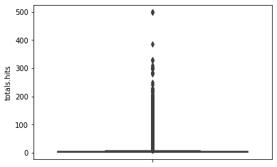

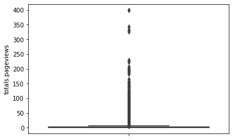

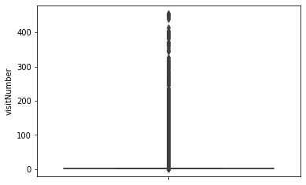

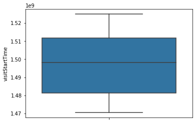

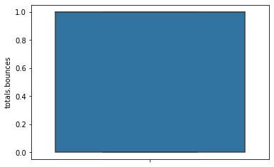

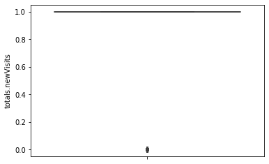

```
Number of dropped instances=  0
```

```python
#2: 3 SD Outliers for numerical variables
num_train = train_df[num_col]
num_target = train_df["totals.transactionRevenue"]
cat_train = train_df[cat_cols]

sn.boxplot( y=train_df['totals.hits']);
plt.show()

sn.boxplot( y=train_df['totals.pageviews']);
plt.show()

sn.boxplot( y=train_df['visitNumber']);
plt.show()

sn.boxplot( y=train_df['visitStartTime']);
plt.show()

sn.boxplot( y=train_df['totals.bounces']);
plt.show()

sn.boxplot( y=train_df['totals.newVisits']);
plt.show()

# we dont remove outliers
idx = np.abs(stats.zscore(num_train, nan_policy='omit')).all(axis=1)

clean_train_df = pd.concat([num_train.loc[idx], cat_train.loc[idx], num_target.loc[idx]], axis=1)
print('Number of dropped instances= ', train_df.shape[0] - clean_train_df.shape[0])
```

```python
#3 Scaling
clean_train_df[num_col] = StandardScaler().fit_transform(clean_train_df[num_col])
```

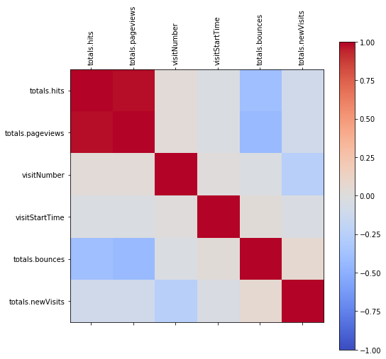

```python
#4 Additivity
X = clean_train_df[num_col]


# Compute correlations between features
corr = X.corr()

# Create a figure pointer or handle
fig = plt.figure(figsize=(8,8)) # Sample figsize in inches
# Add a 1x1 subplot at index 1 to fig
ax  = fig.add_subplot(111)

# Plots a matrix using corr
cax = ax.matshow(corr,cmap='coolwarm', vmin=-1, vmax=1)
fig.colorbar(cax)

# Add ticks for each feature
ticks = np.arange(0,len(X.columns),1)
ax.set_xticks(ticks)
plt.xticks(rotation=90)
ax.set_yticks(ticks)

# Add column names as tick labels
ax.set_xticklabels(X.columns)
ax.set_yticklabels(X.columns)
plt.show()
```

```python
# Drop High correlations - dependent variables are too similar

# Create correlation matrix
corr_matrix = X.corr().abs()

# Select upper triangle of correlation matrix
upper = corr_matrix.where(np.triu(np.ones(corr_matrix.shape), k=1).astype(np.bool))

# Find index of feature columns with correlation greater than 0.60
to_drop = [column for column in upper.columns if any(upper[column] > 0.6)]

print(to_drop)
clean_train_df = clean_train_df.drop(["totals.pageviews"],axis=1)

num_col = ["totals.hits","visitNumber", "visitStartTime", 'totals.bounces',  'totals.newVisits']
```

```
['totals.pageviews']
```

```python
# Shows correlation values of above graph
corr
```

|  | totals.hits | totals.pageviews | visitNumber | visitStartTime | totals.bounces | totals.newVisits |
| --- | --- | --- | --- | --- | --- | --- |
| totals.hits | 1.000000 | 0.980973 | 0.033261 | -0.026801 | -0.386904 | -0.096536 |
| totals.pageviews | 0.980973 | 1.000000 | 0.036186 | -0.029749 | -0.425018 | -0.099487 |
| visitNumber | 0.033261 | 0.036186 | 1.000000 | 0.011454 | -0.023938 | -0.256712 |
| visitStartTime | -0.026801 | -0.029749 | 0.011454 | 1.000000 | 0.024973 | -0.034994 |
| totals.bounces | -0.386904 | -0.425018 | -0.023938 | 0.024973 | 1.000000 | 0.070169 |
| totals.newVisits | -0.096536 | -0.099487 | -0.256712 | -0.034994 | 0.070169 | 1.000000 |

We can see that the total hits and total page views are highly correlated and so we will be dropping the total page views from our model.

# Model 1: K Means - Clustering

```python
clustering_df = clean_train_df[['channelGrouping', 'device.deviceCategory','trafficSource.source', 'trafficSource.medium']]
```

```python
clustering_df.describe()
```

|  | channelGrouping | device.deviceCategory | trafficSource.source | trafficSource.medium |
| --- | --- | --- | --- | --- |
| count | 300000.000000 | 300000.000000 | 300000.000000 | 300000.000000 |
| mean | 4.500383 | 0.354667 | 64.772917 | 3.319180 |
| std | 1.745269 | 0.552141 | 74.095602 | 2.596219 |
| min | 0.000000 | 0.000000 | 0.000000 | 0.000000 |
| 25% | 4.000000 | 0.000000 | 0.000000 | 0.000000 |
| 50% | 4.000000 | 0.000000 | 56.000000 | 5.000000 |
| 75% | 6.000000 | 1.000000 | 56.000000 | 6.000000 |
| max | 7.000000 | 2.000000 | 199.000000 | 6.000000 |

# Optimum K:

We use the elbow method to identify optimal number of clusters.

```python
sum_of_squared_distances = []
K = range (1,7,1)
for k in K:
    print(k)
    km = KMeans(n_clusters=k)
    km = km.fit(clustering_df)
    sum_of_squared_distances.append(km.inertia_)
```

```
1
2
3
4
5
6
```

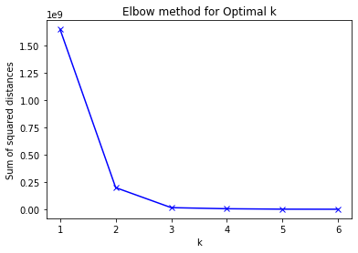

```python
plt.plot(K, sum_of_squared_distances, 'bx-')
plt.xlabel('k')
plt.ylabel('Sum of squared distances')
plt.title('Elbow method for Optimal k')
plt.show()
```

The elbow method shows that the optimal number of clusters is 3. The next step is to design a Kmeans clustering model.

# Model 1:

We develop a K-Means Clustering model with 3 clusters as identified in the previous step.

```python
kmeans = KMeans(n_clusters = 3, random_state = 76964057).fit(clustering_df)
```

```python
pd.Series(kmeans.labels_).value_counts()
```

```
2    121604
0    112388
1     66008
dtype: int64
```

```python
clustering_df['KMeans_id'] = pd.Series(kmeans.labels_, index = clustering_df.index)
clean_train_df['KMeans_id'] = pd.Series(kmeans.labels_, index = clustering_df.index)
```

```python
clustering_df.query("KMeans_id==1")
```

|  | channelGrouping | device.deviceCategory | trafficSource.source | trafficSource.medium | KMeans_id |
| --- | --- | --- | --- | --- | --- |
| 1 | 6 | 0 | 174 | 6 | 1 |
| 6 | 6 | 0 | 174 | 6 | 1 |
| 227 | 6 | 0 | 174 | 6 | 1 |
| 494 | 6 | 0 | 157 | 6 | 1 |
| 496 | 6 | 0 | 163 | 6 | 1 |
| ... | ... | ... | ... | ... | ... |
| 299845 | 6 | 1 | 133 | 6 | 1 |
| 299918 | 6 | 0 | 173 | 6 | 1 |
| 299940 | 6 | 0 | 163 | 6 | 1 |
| 299962 | 6 | 1 | 173 | 6 | 1 |
| 299985 | 6 | 0 | 133 | 6 | 1 |

66008 rows × 5 columns

```python
#drop the variables part of K-Means
Model1_out_df = clean_train_df.drop(['channelGrouping', 'device.deviceCategory','trafficSource.source', 'trafficSource.medium'],axis=1)
```

## Classifier Target Variable creation:

We create a binary yes (1) or no (0) variable that corresponds to if the transaction is a revenue transaction or not.

```python
#Def target variable

def revenue_to_categorical(x):
    if x > 0.0:
        return 1
    else:
        return 0

target = Model1_out_df["totals.transactionRevenue"].apply(revenue_to_categorical)

#drop the transaction revenue variable
Model2_in_df = Model1_out_df.drop(["totals.transactionRevenue"],axis=1)
```

## Train and Test Split:

We use the 80/20 rule to generate a training (80) and test (20) dataset.

```python
X_train, X_test, y_train, y_test = train_test_split(Model2_in_df, target, test_size=0.20, random_state=52)
```

## Undersampling:

As out dataset is heavily skewed towards non revenue customers we use undersampling technique to develop the model data.

```python
#resampling population
train_data = pd.concat([X_train, y_train], axis=1)

# separate the skewed data
negative = train_data[train_data["totals.transactionRevenue"]==0]
positive = train_data[train_data["totals.transactionRevenue"]==1]

# downsample majority skewed data
neg_downsampled = resample(negative, replace=True, n_samples=len(positive), random_state=32)

# combine minority and downsampled majority
downsampled = pd.concat([positive, neg_downsampled])

X_train_new = downsampled.drop(["totals.transactionRevenue"],axis=1)
y_train_new = downsampled["totals.transactionRevenue"]

# check new counts
downsampled["totals.transactionRevenue"].value_counts()
```

```
1    2498
0    2498
Name: totals.transactionRevenue, dtype: int64
```

# Model 2: Random Forest Classifer

We use the undersampled output from clustering as input into the random forrest classifier model to determine if the customer is a revenue customer or non-revenue customer.

```python
rf_model = RandomForestClassifier(n_estimators=100, criterion="gini", max_depth=6, min_samples_leaf=5, random_state=12345)
rf_model.fit(X_train_new, y_train_new)
```

```
RandomForestClassifier(bootstrap=True, ccp_alpha=0.0, class_weight=None,
                       criterion='gini', max_depth=6, max_features='auto',
                       max_leaf_nodes=None, max_samples=None,
                       min_impurity_decrease=0.0, min_impurity_split=None,
                       min_samples_leaf=5, min_samples_split=2,
                       min_weight_fraction_leaf=0.0, n_estimators=100,
                       n_jobs=None, oob_score=False, random_state=12345,
                       verbose=0, warm_start=False)
```

```python
# Feature Importance
feature_importances = pd.DataFrame(rf_model.feature_importances_,
                                   index = X_train_new.columns,
                                   columns=['importance']).sort_values('importance',
                                                                       ascending=False)
feature_importances[0:5]
```

|  | importance |
| --- | --- |
| totals.hits | 0.506182 |
| totals.bounces | 0.127025 |
| geoNetwork.country | 0.116474 |
| geoNetwork.continent | 0.066821 |
| geoNetwork.subContinent | 0.053300 |

```
[0.95978391 0.95915916 0.94474474]

Accuracy: 0.95 (std 0.01)
Confusion Matrix:

[[2332  166]
 [  61 2437]]
```

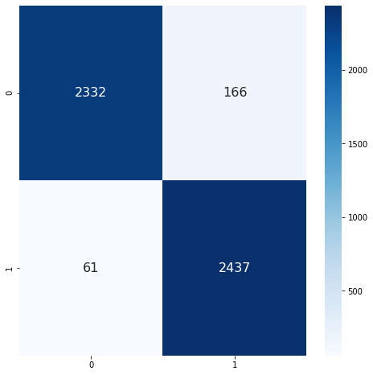

```python
scores    = cross_val_score(rf_model, X_train_new, y_train_new, cv=3, scoring="accuracy")
y_predict = cross_val_predict(rf_model, X_train_new, y_train_new, cv=3)

print(scores)
print("\nAccuracy: %0.2f (std %0.2f)" % (scores.mean(), scores.std()))

CM = confusion_matrix(y_train_new, y_predict)
print("Confusion Matrix: \n")
print(CM)

# Visualize it as a heatmap
fig, ax = plt.subplots(figsize=(8,8))
akws = {"ha": 'center',"va": 'center', "size": 16}
sn.heatmap(CM, fmt='', cmap=plt.cm.Blues, annot=True,annot_kws=akws, ax=ax)
```

## Random Forest Classifier testing:

```
Confusion Matrix:

[[55136  4208]
 [   14   642]]

Accuracy: 92.96333333333334 pct
```

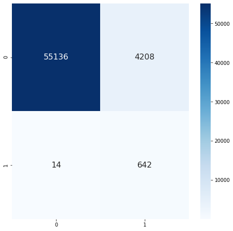

```python
# Using test features data, predict test
y_predict = rf_model.predict(X_test)

CM = confusion_matrix(y_test, y_predict)
print("Confusion Matrix: \n")

print(CM)

# Visualize it as a heatmap
fig, ax = plt.subplots(figsize=(8,8))

sn.heatmap(CM, fmt='', cmap=plt.cm.Blues, annot=True,annot_kws=akws, ax=ax)

print("\nAccuracy: " + str(accuracy_score(y_test, y_predict) * 100) + " pct\n")
```

```python
target_names = ['Non-Revenue', 'Revenue']

print(classification_report(y_test, y_predict, target_names=target_names))
```

```
              precision    recall  f1-score   support

 Non-Revenue       1.00      0.93      0.96     59344
     Revenue       0.13      0.98      0.23       656

    accuracy                           0.93     60000
   macro avg       0.57      0.95      0.60     60000
weighted avg       0.99      0.93      0.96     60000
```

# Model 3: Logistic Regression model

We use the undersampled output from clustering as input into the logistic regression model to determine if the customer is a revenue customer or non-revenue customer.

```python
logmodel  = LogisticRegression(solver='saga', max_iter = 1000)
logmodel.fit(X_train_new, y_train_new)
```

```
LogisticRegression(C=1.0, class_weight=None, dual=False, fit_intercept=True,
                   intercept_scaling=1, l1_ratio=None, max_iter=1000,
                   multi_class='auto', n_jobs=None, penalty='l2',
                   random_state=None, solver='saga', tol=0.0001, verbose=0,
                   warm_start=False)
```

```
[0.73409364 0.73273273 0.71651652]

Accuracy: 0.73 (std 0.01)
Confusion Matrix:

[[1716  782]
 [ 578 1920]]
```

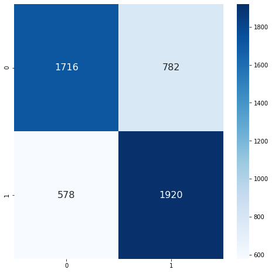

```python
scores    = cross_val_score(logmodel, X_train_new, y_train_new, cv=3, scoring="accuracy")
y_predict = cross_val_predict(logmodel, X_train_new, y_train_new, cv=3)

print(scores)
print("\nAccuracy: %0.2f (std %0.2f)" % (scores.mean(), scores.std()))

CM = confusion_matrix(y_train_new, y_predict)
print("Confusion Matrix: \n")
print(CM)

# Visualize it as a heatmap
fig, ax = plt.subplots(figsize=(8,8))

akws = {"ha": 'center',"va": 'center', "size": 16}

sn.heatmap(CM, fmt='', cmap=plt.cm.Blues, annot=True,annot_kws=akws, ax=ax)
```

## Logistic Regression model testing:

```
Confusion Matrix:

[[41123 18221]
 [  126   530]]

Accuracy: 69.42166666666667 pct
```

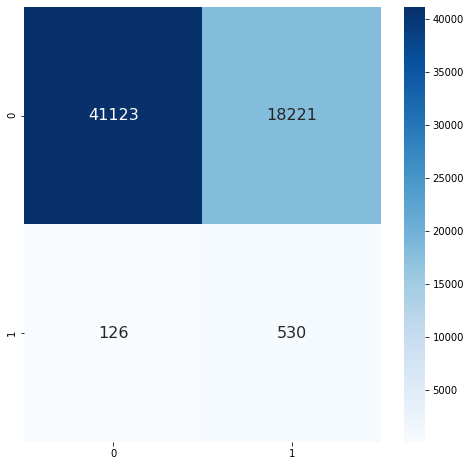

```python
# Using test features data, predict test
y_predict = logmodel.predict(X_test)

CM = confusion_matrix(y_test, y_predict)
print("Confusion Matrix: \n")

print(CM)

# Visualize it as a heatmap
fig, ax = plt.subplots(figsize=(8,8))

sn.heatmap(CM, fmt='', cmap=plt.cm.Blues, annot=True,annot_kws=akws, ax=ax)

print("\nAccuracy: " + str(accuracy_score(y_test, y_predict) * 100) + " pct\n")
```

```python
target_names = ['Non-Revenue', 'Revenue']

print(classification_report(y_test, y_predict, target_names=target_names))
```

```
              precision    recall  f1-score   support

 Non-Revenue       1.00      0.69      0.82     59344
     Revenue       0.03      0.81      0.05       656

    accuracy                           0.69     60000
   macro avg       0.51      0.75      0.44     60000
weighted avg       0.99      0.69      0.81     60000
```

# Model 4: Naïve Bayes Classifier

We use the undersampled output from clustering as input into the Naive Bayes model to determine if the customer is a revenue customer or non-revenue customer.

```python
gnb = GaussianNB()
gnb = gnb.fit(X_train_new, y_train_new)
```

```
[0.85954382 0.85585586 0.84144144]

Accuracy: 0.85 (std 0.01)
Confusion Matrix:

[[1934  564]
 [ 174 2324]]
```

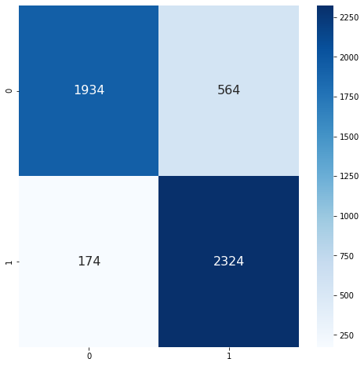

```python
scores    = cross_val_score(gnb, X_train_new, y_train_new, cv=3, scoring="accuracy")
y_predict = cross_val_predict(gnb, X_train_new, y_train_new, cv=3)

print(scores)
print("\nAccuracy: %0.2f (std %0.2f)" % (scores.mean(), scores.std()))

CM = confusion_matrix(y_train_new, y_predict)
print("Confusion Matrix: \n")
print(CM)

# Visualize it as a heatmap
fig, ax = plt.subplots(figsize=(8,8))

akws = {"ha": 'center',"va": 'center', "size": 16}

sn.heatmap(CM, fmt='', cmap=plt.cm.Blues, annot=True,annot_kws=akws, ax=ax)
```

## Naive Bayes model testing:

```
Confusion Matrix:

[[46453 12891]
 [   44   612]]

Accuracy: 78.44166666666666 pct
```

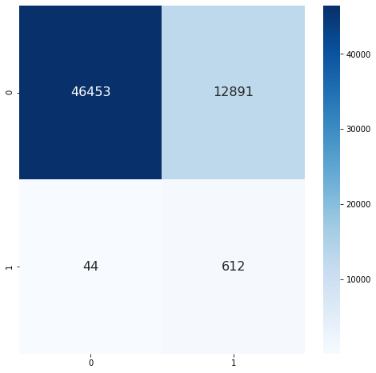

```python
# Using test features data, predict test
y_predict = gnb.predict(X_test)

CM = confusion_matrix(y_test, y_predict)
print("Confusion Matrix: \n")

print(CM)

# Visualize it as a heatmap
fig, ax = plt.subplots(figsize=(8,8))

sn.heatmap(CM, fmt='', cmap=plt.cm.Blues, annot=True,annot_kws=akws, ax=ax)

print("\nAccuracy: " + str(accuracy_score(y_test, y_predict) * 100) + " pct\n")
```

```python
target_names = ['Non-Revenue', 'Revenue']

print(classification_report(y_test, y_predict, target_names=target_names))
```

```
              precision    recall  f1-score   support

 Non-Revenue       1.00      0.78      0.88     59344
     Revenue       0.05      0.93      0.09       656

    accuracy                           0.78     60000
   macro avg       0.52      0.86      0.48     60000
weighted avg       0.99      0.78      0.87     60000
```

# Model 5: PCA Iteration with Random Forest Classifier

As our data is skewed we use Recall as the metric to evaluate the best model. Based on the three models evaluated above Random Forest classifier has the highest recall value and we will use prinicipal component analysis with random forest to see if we have any further improvement.

```python
#Fitting the PCA algorithm with our Data
pca = PCA().fit(X_train_new)
```

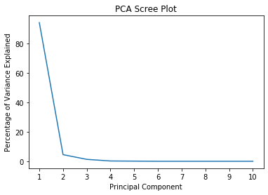

```python
percent_variance = np.round(pca.explained_variance_ratio_* 100, decimals =1)
plt.plot(range(1,11), percent_variance[:10])
plt.ylabel('Percentage of Variance Explained')
plt.xlabel('Principal Component')
plt.title('PCA Scree Plot')
plt.xticks(range(1,11))
plt.show()
```

```python
percent_variance
```

```
array([94. ,  4.5,  1.3,  0.2,  0.1,  0. ,  0. ,  0. ,  0. ,  0. ,  0. ,
        0. ,  0. ,  0. ,  0. ,  0. ,  0. ,  0. ,  0. ,  0. ,  0. ,  0. ,
        0. ,  0. ,  0. ])
```

## Optimal Principal Component count:

Based on the scree plot we can see that the inflection point is in PCA 2 and therefore the optimal number of principal components is 2 which explains 98.4% of the variance in data.

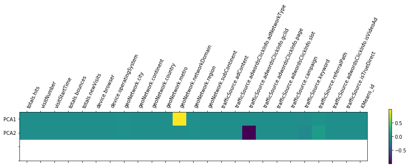

```python
# Visualizing PCA

#Fitting the PCA algorithm with our Data
pca_v2=PCA(n_components=2)
pca_v2 = pca_v2.fit(X_train_new)

plt.matshow(pca_v2.components_,cmap='viridis')
plt.yticks([0,1,2,3],['PCA1','PCA2'],fontsize=10)
plt.colorbar()
plt.xticks(range(len(X_train_new.columns)),X_train_new.columns,rotation=65,ha='left')
plt.show()
```

## RF Classifier with PCA:

```python
#Fitting the PCA algorithm with our Data
pca = PCA(n_components=2).fit(X_train_new)
X_train_pca = pca.fit_transform(X_train_new)
X_test_pca = pca.fit_transform(X_test)

rf_pca_model = RandomForestClassifier(n_estimators=100, criterion="gini",  # "gini" or "entropy"
                                       max_depth=6, min_samples_leaf=5)
rf_pca_model.fit(X_train_pca, y_train_new)
```

```
RandomForestClassifier(bootstrap=True, ccp_alpha=0.0, class_weight=None,
                       criterion='gini', max_depth=6, max_features='auto',
                       max_leaf_nodes=None, max_samples=None,
                       min_impurity_decrease=0.0, min_impurity_split=None,
                       min_samples_leaf=5, min_samples_split=2,
                       min_weight_fraction_leaf=0.0, n_estimators=100,
                       n_jobs=None, oob_score=False, random_state=None,
                       verbose=0, warm_start=False)
```

```
[0.73469388 0.73873874 0.74774775]

Accuracy: 0.74 (std 0.01)
Confusion Matrix:

[[1922  576]
 [ 701 1797]]
```

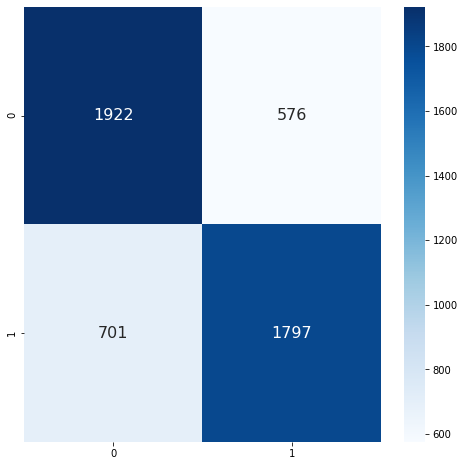

```python
scores    = cross_val_score(rf_pca_model, X_train_pca, y_train_new, cv=3, scoring="accuracy")
y_predict = cross_val_predict(rf_pca_model, X_train_pca, y_train_new, cv=3)

print(scores)
print("\nAccuracy: %0.2f (std %0.2f)" % (scores.mean(), scores.std()))

CM = confusion_matrix(y_train_new, y_predict)
print("Confusion Matrix: \n")
print(CM)

# Visualize it as a heatmap
fig, ax = plt.subplots(figsize=(8,8))

akws = {"ha": 'center',"va": 'center', "size": 16}

sn.heatmap(CM, fmt='', cmap=plt.cm.Blues, annot=True,annot_kws=akws, ax=ax)
```

## PCA Iteration testing:

```
Confusion Matrix:

[[34663 24681]
 [  202   454]]

Accuracy: 58.528333333333336 pct
```

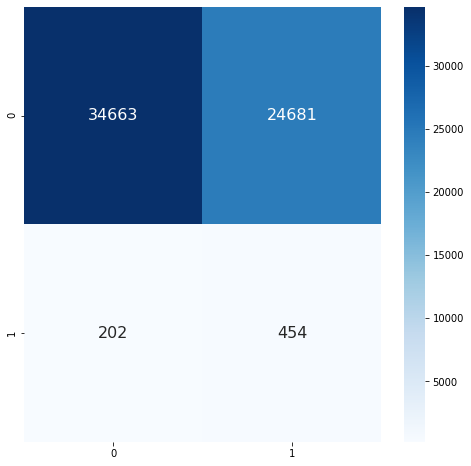

```python
# Using test features data, predict test
y_predict = rf_pca_model.predict(X_test_pca)

CM = confusion_matrix(y_test, y_predict)
print("Confusion Matrix: \n")

print(CM)

# Visualize it as a heatmap
fig, ax = plt.subplots(figsize=(8,8))

sn.heatmap(CM, fmt='', cmap=plt.cm.Blues, annot=True,annot_kws=akws, ax=ax)

print("\nAccuracy: " + str(accuracy_score(y_test, y_predict) * 100) + " pct\n")
```

```python
target_names = ['Non-Revenue', 'Revenue']

print(classification_report(y_test, y_predict, target_names=target_names))
```

```
              precision    recall  f1-score   support

 Non-Revenue       0.99      0.58      0.74     59344
     Revenue       0.02      0.69      0.04       656

    accuracy                           0.59     60000
   macro avg       0.51      0.64      0.39     60000
weighted avg       0.98      0.59      0.73     60000
```

Reducing the dimensions using principal component analysis did not improve the performance of random forest classifier.